# Prediction_Cal,Carbon_from_Time

## 사용시간<->이동거리

## 이동거리<->탄소량의 관계를 데이터 분석하여

## 예상 사용시간을 입력하면 예측 이동거리를 통해

## 예측 운동량과 예측 탄소량을 알려주도록 데이터를 분석함

```python
import pandas as pd
import numpy as np
from sklearn.linear_model import LinearRegression
import matplotlib.pyplot as plt
import seaborn as sns
sns.set()
import warnings
warnings.filterwarnings(action='ignore')
```

```python
df1 = pd.read_csv("D:/OA-15245/서울특별시 공공자전거 이용정보(시간대별)_2017년_1.csv", encoding="EUC-KR",sep=",", engine="python", na_values="\"\"", error_bad_lines=False, warn_bad_lines=False,quotechar="'")
df2 = pd.read_csv("D:/OA-15245/서울특별시 공공자전거 이용정보(시간대별)_2017년_2.csv", encoding="EUC-KR",sep=",", engine="python", na_values="\"\"", error_bad_lines=False, warn_bad_lines=False,quotechar="'")
df3 = pd.read_csv("D:/OA-15245/서울특별시 공공자전거 이용정보(시간대별)_2017년_3.csv", encoding="EUC-KR",sep=",", engine="python", na_values="\"\"", error_bad_lines=False, warn_bad_lines=False,quotechar="'")
df4 = pd.read_csv("D:/OA-15245/서울특별시 공공자전거 이용정보(시간대별)_2017년_4.csv", encoding="EUC-KR",sep=",", engine="python", na_values="\"\"", error_bad_lines=False, warn_bad_lines=False,quotechar="'")
df5 = pd.read_csv("D:/OA-15245/서울특별시 공공자전거 이용정보(시간대별)_2017년_5.csv", encoding="EUC-KR",sep=",", engine="python", na_values="\"\"", error_bad_lines=False, warn_bad_lines=False,quotechar="'")
df6 = pd.read_csv("D:/OA-15245/서울특별시 공공자전거 이용정보(시간대별)_2017년_6.csv", encoding="EUC-KR",sep=",", engine="python", na_values="\"\"", error_bad_lines=False, warn_bad_lines=False, quotechar="'")
```

```python
df7 = pd.read_excel("D:/OA-15245/서울특별시 공공자전거 시간대별 대여정보_201801_02.xlsx", head=1)
df8 = pd.read_excel("D:/OA-15245/서울특별시 공공자전거 시간대별 대여정보_201803_04.xlsx", head=1)
df9 = pd.read_excel("D:/OA-15245/서울특별시 공공자전거 시간대별 대여정보_201805.xlsx", head=1)
df10 = pd.read_excel("D:/OA-15245/서울특별시 공공자전거 시간대별 대여정보_201806.xlsx", head=1)
df11 = pd.read_excel("D:/OA-15245/서울특별시 공공자전거 시간대별 대여정보_201807.xlsx", head=1)
df12 = pd.read_excel("D:/OA-15245/서울특별시 공공자전거 시간대별 대여정보_201808.xlsx", head=1)
df13 = pd.read_excel("D:/OA-15245/서울특별시 공공자전거 시간대별 대여정보_201809.xlsx", head=1)
df14 = pd.read_excel("D:/OA-15245/서울특별시 공공자전거 시간대별 대여정보_201810.xlsx", head=1)
df15 = pd.read_excel("D:/OA-15245/서울특별시 공공자전거 시간대별 대여정보_201811.xlsx", head=1)
```

```python
df16 = pd.read_csv("D:/OA-15245/서울특별시 공공자전거 시간대별 대여정보_201812~201905.csv",sep=",", engine="python", na_values="\"\"", error_bad_lines=False, warn_bad_lines=False, quotechar="\"")
df17 = pd.read_csv("D:/OA-15245/서울특별시 공공자전거 시간대별 대여정보_201812~201905(1).csv", sep=",", engine="python", na_values="\"\"", error_bad_lines=False, warn_bad_lines=False, quotechar="\"")
df18 = pd.read_csv("D:/OA-15245/서울특별시 공공자전거 시간대별 대여정보_201812~201905(2).csv", sep=",", engine="python", na_values="\"\"", error_bad_lines=False, warn_bad_lines=False, quotechar="\"")
df19 = pd.read_csv("D:/OA-15245/서울특별시 공공자전거 시간대별 대여정보_201812~201905(3).csv", sep=",", engine="python", na_values="\"\"", error_bad_lines=False, warn_bad_lines=False, quotechar="\"")
df20 = pd.read_csv("D:/OA-15245/서울특별시 공공자전거 시간대별 대여정보_201812~201905(4).csv", sep=",", engine="python", na_values="\"\"", error_bad_lines=False, warn_bad_lines=False, quotechar="\"")
df21 = pd.read_csv("D:/OA-15245/서울특별시 공공자전거 시간대별 대여정보_201812~201905(5).csv", sep=",", engine="python", na_values="\"\"", error_bad_lines=False, warn_bad_lines=False, quotechar="\"")
```

```python
df22 = pd.read_csv("D:/OA-15245/서울특별시 공공자전거 이용정보(시간대별)_20190601_20191130(1).csv", sep=",", engine="python", na_values="\"\"", error_bad_lines=False,  quotechar="\"")
df23 = pd.read_csv("D:/OA-15245/서울특별시 공공자전거 이용정보(시간대별)_20190601_20191130(2).csv", sep=",", engine="python", na_values="\"\"", error_bad_lines=False,  quotechar="\"")
df24 = pd.read_csv("D:/OA-15245/서울특별시 공공자전거 이용정보(시간대별)_20190601_20191130(3).csv", sep=",", engine="python", na_values="\"\"", error_bad_lines=False,  quotechar="\"")
df25 = pd.read_csv("D:/OA-15245/서울특별시 공공자전거 이용정보(시간대별)_20190601_20191130(4).csv", sep=",", engine="python", na_values="\"\"", error_bad_lines=False,  quotechar="\"")
df26 = pd.read_csv("D:/OA-15245/서울특별시 공공자전거 이용정보(시간대별)_20190601_20191130(5).csv", sep=",", engine="python", na_values="\"\"", error_bad_lines=False,  quotechar="\"")
df27 = pd.read_csv("D:/OA-15245/서울특별시 공공자전거 이용정보(시간대별)_20190601_20191130(6).csv", sep=",", engine="python", na_values="\"\"", error_bad_lines=False,  quotechar="\"")
df28 = pd.read_csv("D:/OA-15245/서울특별시 공공자전거 이용정보(시간대별)_20190601_20191130(7).csv", sep=",", engine="python", na_values="\"\"", error_bad_lines=False,  quotechar="\"")
df29 = pd.read_csv("D:/OA-15245/서울특별시 공공자전거 이용정보(시간대별)_20190601_20191130(8).csv", sep=",", engine="python", na_values="\"\"", error_bad_lines=False,  quotechar="\"")
df30 = pd.read_csv("D:/OA-15245/서울특별시 공공자전거 이용정보(시간대별)_20190601_20191130(9).csv", sep=",", engine="python", na_values="\"\"", error_bad_lines=False,  quotechar="\"")
df31 = pd.read_csv("D:/OA-15245/서울특별시 공공자전거 이용정보(시간대별)_20190601_20191130(10).csv", sep=",", engine="python", na_values="\"\"", error_bad_lines=False,  quotechar="\"")
```

```python
df1.head(1)
```

|  | 대여일자 | 대여시간 | 대여소번호 | 대여소 | 대여구분코드 | 성별 | 연령대코드 | 이용건수 | 운동량 | 탄소량 | 이동거리(M) | 이동시간(분) |
| --- | --- | --- | --- | --- | --- | --- | --- | --- | --- | --- | --- | --- |
| 0 | 2017-01-01 | 0 | 230 | 영등포구청역 1번출구 | 정기 | F | ~10대 | 1 | 31.27 | 0.39 | 1680 | 155 |

```python
df2.head(1)
```

|  | 대여일자 | 대여시간 | 대여소번호 | 대여소 | 대여구분코드 | 성별 | 연령대코드 | 이용건수 | 운동량 | 탄소량 | 이동거리(M) | 이동시간(분) |
| --- | --- | --- | --- | --- | --- | --- | --- | --- | --- | --- | --- | --- |
| 0 | 2017-06-01 | 0 | 301 | 경복궁역 7번출구 앞 | 정기 | F | 20대 | 2 | 315.77 | 2.7 | 11640 | 98 |

```python
df3.head(1)
```

|  | 대여일자 | 대여시간 | 대여소번호 | 대여소 | 대여구분코드 | 성별 | 연령대코드 | 이용건수 | 운동량 | 탄소량 | 이동거리(M) | 이동시간(분) |
| --- | --- | --- | --- | --- | --- | --- | --- | --- | --- | --- | --- | --- |
| 0 | 2017-08-01 | 0 | 538 | 답십리역 8번출구 앞 | 정기 | F | ~10대 | 1 | 34.06 | 0.42 | 1830 | 13 |

```python
df4.head(1)
```

|  | 대여일자 | 대여시간 | 대여소번호 | 대여소 | 대여구분코드 | 성별 | 연령대코드 | 이용건수 | 운동량 | 탄소량 | 이동거리(M) | 이동시간(분) |
| --- | --- | --- | --- | --- | --- | --- | --- | --- | --- | --- | --- | --- |
| 0 | 2017-09-01 | 0 | 313 | 서울역 광장 파출소 옆 | 정기 | F | ~10대 | 1 | 54.62 | 0.48 | 2090 | 11 |

```python
df5.head(1)
```

|  | 대여일자 | 대여시간 | 대여소번호 | 대여소 | 대여구분코드 | 성별 | 연령대코드 | 이용건수 | 운동량 | 탄소량 | 이동거리(M) | 이동시간(분) |
| --- | --- | --- | --- | --- | --- | --- | --- | --- | --- | --- | --- | --- |
| 0 | 2017-10-01 | 0 | 509 | 이마트 버스정류소 옆 | 정기 | F | ~10대 | 1 | 182.95 | 1.95 | 8400 | 51 |

```python
df6.head(1)
```

|  | 대여일자 | 대여시간 | 대여소번호 | 대여소 | 대여구분코드 | 성별 | 연령대코드 | 이용건수 | 운동량 | 탄소량 | 이동거리(M) | 이동시간(분) |
| --- | --- | --- | --- | --- | --- | --- | --- | --- | --- | --- | --- | --- |
| 0 | 2017-11-01 | 0 | 337 | 창경궁 입구 | 정기 | F | ~10대 | 1 | 10.04 | 0.09 | 390 | 3 |

```python
df7.head(1)
```

|  | 대여일자 | 대여시간 | 대여소번호 | 대여소명 | 대여구분코드 | 성별 | 연령대코드 | 이용건수 | 운동량 | 탄소량 | 이동거리 | 이동시간 |
| --- | --- | --- | --- | --- | --- | --- | --- | --- | --- | --- | --- | --- |
| 0 | 2018-01-01 | 0 | 300 | 정동사거리 | 정기권 | F | ~10대 | 1 | 37.32 | 0.34 | 1450 | 23 |

```python
df8.head(1)
```

|  | 대여일자 | 대여시간 | 대여소번호 | 대여소명 | 대여구분코드 | 성별 | 연령대코드 | 이용건수 | 운동량 | 탄소량 | 이동거리 | 이동시간 |
| --- | --- | --- | --- | --- | --- | --- | --- | --- | --- | --- | --- | --- |
| 0 | 2018-03-01 | 0 | 639 | 서울시립대 후문 | 정기권 | F | 20대 | 1 | 40.41 | 0.36 | 1570 | 7 |

```python
df9.head(1)
```

|  | 대여일자 | 대여시간 | 대여소번호 | 대여소명 | 대여구분코드 | 성별 | 연령대코드 | 이용건수 | 운동량 | 탄소량 | 이동거리 | 이동시간 |
| --- | --- | --- | --- | --- | --- | --- | --- | --- | --- | --- | --- | --- |
| 0 | 2018-05-01 | 0 | 737 | 장수공원 | 정기권 | F | ~10대 | 1 | 112.17 | 1.19 | 5150 | 26 |

```python
df10.head(1)
```

|  | 대여일자 | 대여시간 | 대여소번호 | 대여소명 | 대여구분코드 | 성별 | 연령대코드 | 이용건수 | 운동량 | 탄소량 | 이동거리 | 이동시간 |
| --- | --- | --- | --- | --- | --- | --- | --- | --- | --- | --- | --- | --- |
| 0 | 2018-06-01 | 0 | 1720 | 도봉구청 옆(중랑천변) | 정기권 | F | ~10대 | 1 | 259.46 | 2.17 | 9360 | 60 |

```python
df11.head(1)
```

|  | 대여일자 | 대여시간 | 대여소번호 | 대여소명 | 대여구분코드 | 성별 | 연령대코드 | 이용건수 | 운동량 | 탄소량 | 이동거리 | 이동시간 |
| --- | --- | --- | --- | --- | --- | --- | --- | --- | --- | --- | --- | --- |
| 0 | 2018-07-01 | 0 | 516 | 광진메디칼 앞 | 정기권 | F | ~10대 | 1 | 109.55 | 1.17 | 5030 | 55 |

```python
df12.head(1)
```

|  | 대여일자 | 대여시간 | 대여소번호 | 대여소명 | 대여구분코드 | 성별 | 연령대코드 | 이용건수 | 운동량 | 탄소량 | 이동거리 | 이동시간 |
| --- | --- | --- | --- | --- | --- | --- | --- | --- | --- | --- | --- | --- |
| 0 | 2018-08-01 | 0 | 1361 | 홍익중고 입구 | 정기권 | F | ~10대 | 1 | 44.79 | 0.4 | 1740 | 11 |

```python
df13.head(1)
```

|  | 대여일자 | 대여시간 | 대여소번호 | 대여소명 | 대여구분코드 | 성별 | 연령대코드 | 이용건수 | 운동량 | 탄소량 | 이동거리 | 이동시간 |
| --- | --- | --- | --- | --- | --- | --- | --- | --- | --- | --- | --- | --- |
| 0 | 2018-09-01 | 0 | 746 | 목동2단지 상가 | 정기권 | F | ~10대 | 1 | 212.78 | 3.28 | 14140 | 67 |

```python
df14.head(1)
```

|  | 대여일자 | 대여시간 | 대여소번호 | 대여소명 | 대여구분코드 | 성별 | 연령대코드 | 이용건수 | 운동량 | 탄소량 | 이동거리 | 이동시간 |
| --- | --- | --- | --- | --- | --- | --- | --- | --- | --- | --- | --- | --- |
| 0 | 2018-10-01 | 0 | 1336 | 성북3교 위 | 정기권 | F | ~10대 | 1 | 73.62 | 0.66 | 2860 | 16 |

```python
df15.head(1)
```

|  | 대여일자 | 대여시간 | 대여소번호 | 대여소명 | 대여구분코드 | 성별 | 연령대코드 | 이용건수 | 운동량 | 탄소량 | 이동거리 | 이동시간 |
| --- | --- | --- | --- | --- | --- | --- | --- | --- | --- | --- | --- | --- |
| 0 | 2018-11-01 | 0 | 1361 | 홍익중고 입구 | 정기권 | F | ~10대 | 1 | 44.02 | 0.4 | 1710 | 9 |

```python
df16.head(5)
```

|  | 2018-12-01 | 00 | 01721 | 1721. 창동역 2번출구 | 정기 | AGE_001 | 정기.1 | 1 | 25.95 | 0.26 | 1130.00 | 4 |
| --- | --- | --- | --- | --- | --- | --- | --- | --- | --- | --- | --- | --- |
| 0 | 2018-12-01 | 0 | 3511 | 3511. 응봉역 1번출구 | 정기 | AGE_001 | 정기 | 1 | 52.59 | 0.39 | 1660.0 | 72 |
| 1 | 2018-12-01 | 0 | 1975 | 1975. 대림역 1번 출입구 밑 | 정기 | AGE_001 | 정기 | 1 | 136.26 | 1.17 | 5060.0 | 21 |
| 2 | 2018-12-01 | 0 | 110 | 110. 사천교 | 정기 | AGE_001 | 정기 | 1 | 17.76 | 0.16 | 690.0 | 2 |
| 3 | 2018-12-01 | 0 | 749 | 749. 이대 목동병원 앞 | 정기 | AGE_001 | 정기 | 1 | 95.67 | 0.70 | 3020.0 | 15 |
| 4 | 2018-12-01 | 0 | 1357 | 1357. 북한산보국문역 | 정기 | AGE_001 | 정기 | 1 | 42.02 | 0.30 | 1310.0 | 12 |

```python
df17.head(5)
```

|  | 대여일자 | 대여시간 | 대여소번호 | 대여소명 | 대여구분코드 | 성별 | 연령대코드 | 이용건수 | 운동량 | 탄소량 | 이동거리 | 사용시간 |
| --- | --- | --- | --- | --- | --- | --- | --- | --- | --- | --- | --- | --- |
| 0 | 2018-12-01 | 0 | 1721 | 1721. 창동역 2번출구 | 정기권 | \N | ~10대 | 1 | 25.95 | 0.26 | 1130.0 | 4 |
| 1 | 2018-12-01 | 0 | 3511 | 3511. 응봉역 1번출구 | 정기권 | \N | ~10대 | 1 | 52.59 | 0.39 | 1660.0 | 72 |
| 2 | 2018-12-01 | 0 | 1975 | 1975. 대림역 1번 출입구 밑 | 정기권 | \N | ~10대 | 1 | 136.26 | 1.17 | 5060.0 | 21 |
| 3 | 2018-12-01 | 0 | 110 | 110. 사천교 | 정기권 | \N | ~10대 | 1 | 17.76 | 0.16 | 690.0 | 2 |
| 4 | 2018-12-01 | 0 | 749 | 749. 이대 목동병원 앞 | 정기권 | \N | ~10대 | 1 | 95.67 | 0.70 | 3020.0 | 15 |

#### 원래 데이터가 30개라고 떴는데 막상 받아보니 31개였다. df16과 df17은 같은 데이터였다.

#### df16은 서울특별시 공공자전거 시간대별 대여정보_201812~201905 이고,

#### df17은 서울특별시 공공자전거 시간대별 대여정보_201812~201905(1) 이다.

#### 같은 데이터인가보다(df16은 잘못 올린듯싶다).

#### 그래서 df16은 무시하겠다.

```python
df18.head(1)
```

|  | 대여일자 | 대여시간 | 대여소번호 | 대여소명 | 대여구분코드 | 성별 | 연령대코드 | 이용건수 | 운동량 | 탄소량 | 이동거리 | 사용시간 |
| --- | --- | --- | --- | --- | --- | --- | --- | --- | --- | --- | --- | --- |
| 0 | 2019-04-13 | 17 | 104 | 104. 합정역 1번출구 앞 | 일일권 | F | 20대 | 3 | 572.92 | 6.14 | 26510.0 | 216 |

```python
df19.head(1)
```

|  | 대여일자 | 대여시간 | 대여소번호 | 대여소명 | 대여구분코드 | 성별 | 연령대코드 | 이용건수 | 운동량 | 탄소량 | 이동거리 | 사용시간 |
| --- | --- | --- | --- | --- | --- | --- | --- | --- | --- | --- | --- | --- |
| 0 | 2019-05-05 | 22 | 613 | 613. 신설동역 10번출구 앞 | 단체권 | NaN | 20대 | 2 | 224.77 | 2.39 | 10320.0 | 105 |

```python
df20.head(1)
```

|  | 대여일자 | 대여시간 | 대여소번호 | 대여소명 | 대여구분코드 | 성별 | 연령대코드 | 이용건수 | 운동량 | 탄소량 | 이동거리 | 사용시간 |
| --- | --- | --- | --- | --- | --- | --- | --- | --- | --- | --- | --- | --- |
| 0 | 2019-05-24 | 9 | 1824 | 1824. 독산근린공원 입구 | 정기권 | NaN | 20대 | 1 | 11.54 | 0.13 | 550.0 | 2 |

```python
df21.head(1)
```

|  | 대여일자 | 대여시간 | 대여소번호 | 대여소명 | 대여구분코드 | 성별 | 연령대코드 | 이용건수 | 운동량 | 탄소량 | 이동거리 | 사용시간 |
| --- | --- | --- | --- | --- | --- | --- | --- | --- | --- | --- | --- | --- |
| 0 | 2019-05-24 | 9 | 1824 | 1824. 독산근린공원 입구 | 정기권 | NaN | 20대 | 1 | 11.54 | 0.13 | 550.0 | 2 |

```python
df22.head(1)
```

|  | 대여일자 | 대여시간 | 대여소번호 | 대여소명 | 대여구분코드 | 성별 | 연령대코드 | 이용건수 | 운동량 | 탄소량 | 이동거리 | 사용시간 |
| --- | --- | --- | --- | --- | --- | --- | --- | --- | --- | --- | --- | --- |
| 0 | 2019-06-01 | 0 | 740 | 740. 으뜸공원 | 정기권 | NaN | ~10대 | 1 | 42.91 | 0.40 | 1720.0 | 10 |

```python
df23.head(1)
```

|  | 대여일자 | 대여시간 | 대여소번호 | 대여소명 | 대여구분코드 | 성별 | 연령대코드 | 이용건수 | 운동량 | 탄소량 | 이동거리 | 사용시간 |
| --- | --- | --- | --- | --- | --- | --- | --- | --- | --- | --- | --- | --- |
| 0 | 2019-06-18 | 18 | 2128 | 2128. 관악구청교차로 | 정기권 | M | 40대 | 1 | 31.71 | 0.21 | 910.0 | 7 |

```python
df24.head(1)
```

|  | 대여일자 | 대여시간 | 대여소번호 | 대여소명 | 대여구분코드 | 성별 | 연령대코드 | 이용건수 | 운동량 | 탄소량 | 이동거리 | 사용시간 |
| --- | --- | --- | --- | --- | --- | --- | --- | --- | --- | --- | --- | --- |
| 0 | 2019-07-04 | 21 | 1327 | 1327. 상월곡역 3번출구 | 정기권 | NaN | 20대 | 2 | 218.89 | 2.29 | 9870.0 | 58 |

```python
df25.head(1)
```

|  | 대여일자 | 대여시간 | 대여소번호 | 대여소명 | 대여구분코드 | 성별 | 연령대코드 | 이용건수 | 운동량 | 탄소량 | 이동거리 | 사용시간 |
| --- | --- | --- | --- | --- | --- | --- | --- | --- | --- | --- | --- | --- |
| 0 | 2019-07-22 | 17 | 2002 | 2002. 노들역 1번출구 | 정기권 | NaN | 30대 | 1 | 350.94 | 3.43 | 14770.0 | 67 |

```python
df26.head(1)
```

|  | 대여일자 | 대여시간 | 대여소번호 | 대여소명 | 대여구분코드 | 성별 | 연령대코드 | 이용건수 | 운동량 | 탄소량 | 이동거리 | 사용시간 |
| --- | --- | --- | --- | --- | --- | --- | --- | --- | --- | --- | --- | --- |
| 0 | 2019-08-14 | 22 | 951 | 951. 연신내역 6번출구옆 | 정기권 | NaN | 20대 | 1 | 78.46 | 0.59 | 2540.0 | 16 |

```python
df27.head(1)
```

|  | 대여일자 | 대여시간 | 대여소번호 | 대여소명 | 대여구분코드 | 성별 | 연령대코드 | 이용건수 | 운동량 | 탄소량 | 이동거리 | 사용시간 |
| --- | --- | --- | --- | --- | --- | --- | --- | --- | --- | --- | --- | --- |
| 0 | 2019-09-02 | 12 | 1425 | 1425. 용마문화복지센터 | 정기권 | M | 20대 | 1 | 0.00 | 0.00 | 0.0 | 6 |

```python
df28.head(1)
```

|  | 대여일자 | 대여시간 | 대여소번호 | 대여소명 | 대여구분코드 | 성별 | 연령대코드 | 이용건수 | 운동량 | 탄소량 | 이동거리 | 사용시간 |
| --- | --- | --- | --- | --- | --- | --- | --- | --- | --- | --- | --- | --- |
| 0 | 2019-09-24 | 2 | 242 | 242. 신길선원가와인아파트 앞 | 정기권 | NaN | 20대 | 1 | 53.22 | 0.65 | 2800.0 | 27 |

```python
df29.head(1)
```

|  | 대여일자 | 대여시간 | 대여소번호 | 대여소명 | 대여구분코드 | 성별 | 연령대코드 | 이용건수 | 운동량 | 탄소량 | 이동거리 | 사용시간 |
| --- | --- | --- | --- | --- | --- | --- | --- | --- | --- | --- | --- | --- |
| 0 | 2019-10-11 | 5 | 121 | 121. 마포소방서 앞 | 정기권 | M | 30대 | 1 | 22.86 | 0.18 | 780.0 | 4 |

```python
df30.head(1)
```

|  | 대여일자 | 대여시간 | 대여소번호 | 대여소명 | 대여구분코드 | 성별 | 연령대코드 | 이용건수 | 운동량 | 탄소량 | 이동거리 | 사용시간 |
| --- | --- | --- | --- | --- | --- | --- | --- | --- | --- | --- | --- | --- |
| 0 | 2019-10-26 | 22 | 2003 | 2003. 사육신공원앞 | 정기권 | F | 70대~ | 1 | 75.12 | 0.63 | 2710.0 | 25 |

```python
df31.head(1)
```

|  | 대여일자 | 대여시간 | 대여소번호 | 대여소명 | 대여구분코드 | 성별 | 연령대코드 | 이용건수 | 운동량 | 탄소량 | 이동거리 | 사용시간 |
| --- | --- | --- | --- | --- | --- | --- | --- | --- | --- | --- | --- | --- |
| 0 | 2019-11-16 | 10 | 415 | 415. DMC역 9번출구 앞 | 정기권 | NaN | 30대 | 1 | 17.96 | 0.17 | 720.0 | 3 |

#### df1-df6, df7-df16, df17-df31 데이터의 차이점이 있다.

#### 각각 2017년, 2018년, 2019년 데이터라 그런가보다.

```python
df1.rename(columns={"대여소":"대여소명", "이동거리(M)":"이동거리", "이동시간(분)":"사용시간"}, inplace=True)
df2.rename(columns={"대여소":"대여소명", "이동거리(M)":"이동거리", "이동시간(분)":"사용시간"}, inplace=True)
df3.rename(columns={"대여소":"대여소명", "이동거리(M)":"이동거리", "이동시간(분)":"사용시간"}, inplace=True)
df4.rename(columns={"대여소":"대여소명", "이동거리(M)":"이동거리", "이동시간(분)":"사용시간"}, inplace=True)
df5.rename(columns={"대여소":"대여소명", "이동거리(M)":"이동거리", "이동시간(분)":"사용시간"}, inplace=True)
df6.rename(columns={"대여소":"대여소명", "이동거리(M)":"이동거리", "이동시간(분)":"사용시간"}, inplace=True)

df7.rename(columns={"대여소":"대여소명", "이동시간":"사용시간"}, inplace=True)
df8.rename(columns={"대여소":"대여소명", "이동시간":"사용시간"}, inplace=True)
df9.rename(columns={"대여소":"대여소명", "이동시간":"사용시간"}, inplace=True)
df10.rename(columns={"대여소":"대여소명", "이동시간":"사용시간"}, inplace=True)
df11.rename(columns={"대여소":"대여소명", "이동시간":"사용시간"}, inplace=True)
df12.rename(columns={"대여소":"대여소명", "이동시간":"사용시간"}, inplace=True)
df13.rename(columns={"대여소":"대여소명", "이동시간":"사용시간"}, inplace=True)
df14.rename(columns={"대여소":"대여소명", "이동시간":"사용시간"}, inplace=True)
df15.rename(columns={"대여소":"대여소명", "이동시간":"사용시간"}, inplace=True)
df16.rename(columns={"대여소":"대여소명", "이동시간":"사용시간"}, inplace=True)
```

```python
df = [df1,df2,df3,df4,df5,df6,df7,df8,df9,df10,df11,df12,df13,df14,df15,df17,df18,df19,df20,df21,df22,df23,df24,df25,df26,df27,df28,df29,df30,df31]
# df16 제외함

df = pd.concat(df, axis=0, join='outer', ignore_index=True)
```

```python
df1 = df1.drop(['대여일자', '대여시간', '대여소번호', '대여소명', '성별', '연령대코드', '이용건수', '운동량', '탄소량', '이동거리', '사용시간'], axis=1)
df2 = df2.drop(['대여일자', '대여시간', '대여소번호', '대여소명', '대여구분코드', '성별', '연령대코드', '이용건수', '운동량', '탄소량', '이동거리', '사용시간'], axis=1)
df3 = df3.drop(['대여일자', '대여시간', '대여소번호', '대여소명', '대여구분코드', '성별', '연령대코드', '이용건수', '운동량', '탄소량', '이동거리', '사용시간'], axis=1)
df4 = df4.drop(['대여일자', '대여시간', '대여소번호', '대여소명', '대여구분코드', '성별', '연령대코드', '이용건수', '운동량', '탄소량', '이동거리', '사용시간'], axis=1)
df5 = df5.drop(['대여일자', '대여시간', '대여소번호', '대여소명', '대여구분코드', '성별', '연령대코드', '이용건수', '운동량', '탄소량', '이동거리', '사용시간'], axis=1)
df6 = df6.drop(['대여일자', '대여시간', '대여소번호', '대여소명', '대여구분코드', '성별', '연령대코드', '이용건수', '운동량', '탄소량', '이동거리', '사용시간'], axis=1)
df7 = df7.drop(['대여일자', '대여시간', '대여소번호', '대여소명', '성별', '연령대코드', '이용건수', '운동량', '탄소량', '이동거리', '사용시간'], axis=1)
df8 = df8.drop(['대여일자', '대여시간', '대여소번호', '대여소명', '대여구분코드', '성별', '연령대코드', '이용건수', '운동량', '탄소량', '이동거리', '사용시간'], axis=1)
df9 = df9.drop(['대여일자', '대여시간', '대여소번호', '대여소명', '대여구분코드', '성별', '연령대코드', '이용건수', '운동량', '탄소량', '이동거리', '사용시간'], axis=1)
df10 = df10.drop(['대여일자', '대여시간', '대여소번호', '대여소명', '대여구분코드', '성별', '연령대코드', '이용건수', '운동량', '탄소량', '이동거리', '사용시간'], axis=1)
df11 = df11.drop(['대여일자', '대여시간', '대여소번호', '대여소명', '대여구분코드', '성별', '연령대코드', '이용건수', '운동량', '탄소량', '이동거리', '사용시간'], axis=1)
df12 = df12.drop(['대여일자', '대여시간', '대여소번호', '대여소명', '대여구분코드', '성별', '연령대코드', '이용건수', '운동량', '탄소량', '이동거리', '사용시간'], axis=1)
df13 = df13.drop(['대여일자', '대여시간', '대여소번호', '대여소명', '대여구분코드', '성별', '연령대코드', '이용건수', '운동량', '탄소량', '이동거리', '사용시간'], axis=1)
df14 = df14.drop(['대여일자', '대여시간', '대여소번호', '대여소명', '대여구분코드', '성별', '연령대코드', '이용건수', '운동량', '탄소량', '이동거리', '사용시간'], axis=1)
df15 = df15.drop(['대여일자', '대여시간', '대여소번호', '대여소명', '대여구분코드', '성별', '연령대코드', '이용건수', '운동량', '탄소량', '이동거리', '사용시간'], axis=1)
df17 = df17.drop(['대여일자', '대여시간', '대여소번호', '대여소명', '성별', '연령대코드', '이용건수', '운동량', '탄소량', '이동거리', '사용시간'], axis=1)
df18 = df18.drop(['대여일자', '대여시간', '대여소번호', '대여소명', '대여구분코드', '성별', '연령대코드', '이용건수', '운동량', '탄소량', '이동거리', '사용시간'], axis=1)
df19 = df19.drop(['대여일자', '대여시간', '대여소번호', '대여소명', '대여구분코드', '성별', '연령대코드', '이용건수', '운동량', '탄소량', '이동거리', '사용시간'], axis=1)
df20 = df20.drop(['대여일자', '대여시간', '대여소번호', '대여소명', '대여구분코드', '성별', '연령대코드', '이용건수', '운동량', '탄소량', '이동거리', '사용시간'], axis=1)
df21 = df21.drop(['대여일자', '대여시간', '대여소번호', '대여소명', '대여구분코드', '성별', '연령대코드', '이용건수', '운동량', '탄소량', '이동거리', '사용시간'], axis=1)
df22 = df22.drop(['대여일자', '대여시간', '대여소번호', '대여소명', '대여구분코드', '성별', '연령대코드', '이용건수', '운동량', '탄소량', '이동거리', '사용시간'], axis=1)
df23 = df23.drop(['대여일자', '대여시간', '대여소번호', '대여소명', '대여구분코드', '성별', '연령대코드', '이용건수', '운동량', '탄소량', '이동거리', '사용시간'], axis=1)
df24 = df24.drop(['대여일자', '대여시간', '대여소번호', '대여소명', '대여구분코드', '성별', '연령대코드', '이용건수', '운동량', '탄소량', '이동거리', '사용시간'], axis=1)
df25 = df25.drop(['대여일자', '대여시간', '대여소번호', '대여소명', '대여구분코드', '성별', '연령대코드', '이용건수', '운동량', '탄소량', '이동거리', '사용시간'], axis=1)
df26 = df26.drop(['대여일자', '대여시간', '대여소번호', '대여소명', '대여구분코드', '성별', '연령대코드', '이용건수', '운동량', '탄소량', '이동거리', '사용시간'], axis=1)
df27 = df27.drop(['대여일자', '대여시간', '대여소번호', '대여소명', '대여구분코드', '성별', '연령대코드', '이용건수', '운동량', '탄소량', '이동거리', '사용시간'], axis=1)
df28 = df28.drop(['대여일자', '대여시간', '대여소번호', '대여소명', '대여구분코드', '성별', '연령대코드', '이용건수', '운동량', '탄소량', '이동거리', '사용시간'], axis=1)
df29 = df29.drop(['대여일자', '대여시간', '대여소번호', '대여소명', '대여구분코드', '성별', '연령대코드', '이용건수', '운동량', '탄소량', '이동거리', '사용시간'], axis=1)
df30 = df30.drop(['대여일자', '대여시간', '대여소번호', '대여소명', '대여구분코드', '성별', '연령대코드', '이용건수', '운동량', '탄소량', '이동거리', '사용시간'], axis=1)
df31 = df31.drop(['대여일자', '대여시간', '대여소번호', '대여소명', '대여구분코드', '성별', '연령대코드', '이용건수', '운동량', '탄소량', '이동거리', '사용시간'], axis=1)
```

```python
df
```

|  | 대여일자 | 대여시간 | 대여소번호 | 대여소명 | 대여구분코드 | 성별 | 연령대코드 | 이용건수 | 운동량 | 탄소량 | 이동거리 | 사용시간 |
| --- | --- | --- | --- | --- | --- | --- | --- | --- | --- | --- | --- | --- |
| 0 | 2017-01-01 | 0 | 230 | 영등포구청역 1번출구 | 정기 | F | ~10대 | 1 | 31.27 | 0.39 | 1680.0 | 155 |
| 1 | 2017-01-01 | 0 | 315 | 신한은행 안국역지점 옆 | 정기 | F | 20대 | 1 | 47.32 | 0.55 | 2390.0 | 15 |
| 2 | 2017-01-01 | 0 | 328 | 탑골공원 앞 | 정기 | F | 20대 | 1 | 57.92 | 0.52 | 2250.0 | 13 |
| 3 | 2017-01-01 | 0 | 175 | 홍연2교옆 | 정기 | F | 20대 | 1 | 133.29 | 1.53 | 6600.0 | 43 |
| 4 | 2017-01-01 | 0 | 817 | 삼각지역 4번출구 앞 | 정기 | F | 20대 | 1 | 33.88 | 0.32 | 1380.0 | 8 |
| 5 | 2017-01-01 | 0 | 906 | 연신내역 5번출구150M 아래 | 정기 | F | 20대 | 1 | 31.24 | 0.37 | 1610.0 | 11 |
| 6 | 2017-01-01 | 0 | 927 | 연신내역 3번출구 인근 | 정기 | F | 20대 | 1 | 113.69 | 0.77 | 3300.0 | 21 |
| 7 | 2017-01-01 | 0 | 307 | 서울역사박물관 앞 | 정기 | F | 30대 | 2 | 109.93 | 1.05 | 4550.0 | 43 |
| 8 | 2017-01-01 | 0 | 327 | 낙원상가 옆 | 정기 | F | 30대 | 1 | 56.63 | 0.51 | 2200.0 | 18 |
| 9 | 2017-01-01 | 0 | 335 | 종로3가역 15번출구 앞 | 정기 | F | 30대 | 1 | 72.5 | 0.83 | 3590.0 | 24 |
| 10 | 2017-01-01 | 0 | 113 | 홍대입구역 2번출구 앞 | 정기 | F | 30대 | 1 | 62.73 | 0.61 | 2640.0 | 16 |
| 11 | 2017-01-01 | 0 | 419 | 홈플러스 앞 | 정기 | F | 30대 | 1 | 85.97 | 0.77 | 3340.0 | 20 |
| 12 | 2017-01-01 | 0 | 716 | 신정6동 주민센터 인근 | 정기 | F | 40대 | 1 | 15.68 | 0.15 | 660.0 | 30 |
| 13 | 2017-01-01 | 0 | 326 | 안국역 5번출구 앞 | 정기 | F | 60대 | 1 | 68.07 | 0.44 | 1910.0 | 14 |
| 14 | 2017-01-01 | 0 | 327 | 낙원상가 옆 | 정기 | F | 60대 | 1 | 11.76 | 0.08 | 330.0 | 4 |
| 15 | 2017-01-01 | 0 | 900 | 은평예술회관 | 정기 | M | ~10대 | 1 | 135.16 | 0.85 | 3670.0 | 19 |
| 16 | 2017-01-01 | 0 | 216 | 삼부아파트1동 앞 | 정기 | M | ~10대 | 1 | 51.14 | 0.48 | 2050.0 | 20 |
| 17 | 2017-01-01 | 0 | 109 | 제일빌딩 앞 | 정기 | M | 20대 | 1 | 15.25 | 0.18 | 770.0 | 6 |
| 18 | 2017-01-01 | 0 | 315 | 신한은행 안국역지점 옆 | 정기 | M | 20대 | 1 | 71.58 | 0.56 | 2410.0 | 16 |
| 19 | 2017-01-01 | 0 | 326 | 안국역 5번출구 앞 | 정기 | M | 20대 | 1 | 107 | 0.9 | 3860.0 | 15 |
| 20 | 2017-01-01 | 0 | 328 | 탑골공원 앞 | 정기 | M | 20대 | 1 | 67.44 | 0.61 | 2620.0 | 16 |
| 21 | 2017-01-01 | 0 | 111 | 상수역 2번출구 앞 | 정기 | M | 20대 | 1 | 80.05 | 0.72 | 3110.0 | 16 |
| 22 | 2017-01-01 | 0 | 334 | 종로3가역 2번출구 뒤 | 정기 | M | 20대 | 1 | 82.76 | 0.56 | 2430.0 | 22 |
| 23 | 2017-01-01 | 0 | 112 | 극동방송국 앞 | 정기 | M | 20대 | 1 | 68.47 | 0.62 | 2660.0 | 14 |
| 24 | 2017-01-01 | 0 | 347 | 동대문역사문화공원역 9번출구 앞 | 정기 | M | 20대 | 1 | 40.99 | 0.32 | 1380.0 | 11 |
| 25 | 2017-01-01 | 0 | 361 | 동묘앞역 1번출구 뒤 | 정기 | M | 20대 | 1 | 101.93 | 0.54 | 2340.0 | 12 |
| 26 | 2017-01-01 | 0 | 114 | 홍대입구역 8번출구 앞 | 정기 | M | 20대 | 1 | 213.9 | 1.93 | 8310.0 | 36 |
| 27 | 2017-01-01 | 0 | 119 | 서강나루 공원 | 정기 | M | 20대 | 1 | 105.61 | 0.88 | 3810.0 | 21 |
| 28 | 2017-01-01 | 0 | 162 | 봉원고가차도 밑 | 정기 | M | 20대 | 1 | 69.3 | 0.58 | 2500.0 | 11 |
| 29 | 2017-01-01 | 0 | 172 | 서대문소방서 | 정기 | M | 20대 | 1 | 674.31 | 5.49 | 23650.0 | 8 |
| ... | ... | ... | ... | ... | ... | ... | ... | ... | ... | ... | ... | ... |
| 23548820 | 2019-11-30 | 23 | 1933 | 1933. 개봉푸르지오아파트 상가 | 일일권 | M | 20대 | 1 | 50.19 | 0.45 | 1950.0 | 8 |
| 23548821 | 2019-11-30 | 23 | 207 | 207. 여의나루역 1번출구 앞 | 일일권 | M | 20대 | 2 | 134.96 | 0.98 | 4260.0 | 23 |
| 23548822 | 2019-11-30 | 23 | 1414 | 1414. 사가정역 1번출구 | 일일권 | M | 20대 | 1 | 125.10 | 1.13 | 4860.0 | 26 |
| 23548823 | 2019-11-30 | 23 | 1946 | 1946. 구로역 광장 | 일일권 | M | 20대 | 1 | 104.73 | 0.81 | 3480.0 | 25 |
| 23548824 | 2019-11-30 | 23 | 1245 | 1245. 문정 법조단지9 | 일일권 | M | 20대 | 1 | 23.56 | 0.20 | 850.0 | 9 |
| 23548825 | 2019-11-30 | 23 | 1925 | 1925. 동양미래대학교 정문 옆 | 일일권 | M | 20대 | 1 | 0.00 | 0.00 | 0.0 | 12 |
| 23548826 | 2019-11-30 | 23 | 2026 | 2026. 흑석역 4번출구 | 일일권 | M | 20대 | 1 | 0.00 | 0.00 | 0.0 | 31 |
| 23548827 | 2019-11-30 | 23 | 390 | 390. 충무로역 1번출구 | 일일권 | M | 20대 | 1 | 202.99 | 2.16 | 9320.0 | 45 |
| 23548828 | 2019-11-30 | 23 | 731 | 731. 서울시 도로환경관리센터 | 일일권 | M | 30대 | 1 | 71.50 | 0.57 | 2440.0 | 17 |
| 23548829 | 2019-11-30 | 23 | 1150 | 1150. 송정역 1번출구 | 일일권 | M | 30대 | 1 | 199.01 | 1.62 | 6980.0 | 40 |
| 23548830 | 2019-11-30 | 23 | 1717 | 1717. 시립창동운동장 입구 | 일일권 | M | 30대 | 1 | 93.56 | 0.73 | 3150.0 | 16 |
| 23548831 | 2019-11-30 | 23 | 2276 | 2276. 영동1교 (양재천근린공원) | 일일권 | M | 30대 | 1 | 18.25 | 0.11 | 480.0 | 2 |
| 23548832 | 2019-11-30 | 23 | 1956 | 1956. 도야미리숯불갈비 앞 | 일일권 | M | 30대 | 1 | 181.13 | 1.34 | 5790.0 | 23 |
| 23548833 | 2019-11-30 | 23 | 2294 | 2294. 두상빌딩 앞 | 일일권 | M | 30대 | 1 | 51.48 | 0.30 | 1300.0 | 10 |
| 23548834 | 2019-11-30 | 23 | 398 | 398. 을지로3가역 3번출구 | 일일권 | M | 30대 | 1 | 35.93 | 0.39 | 1680.0 | 9 |
| 23548835 | 2019-11-30 | 23 | 342 | 342. 대학로 마로니에공원 | 일일권 | M | 30대 | 1 | 55.60 | 0.50 | 2160.0 | 11 |
| 23548836 | 2019-11-30 | 23 | 245 | 245. 삼성생명 당산사옥 앞 | 일일권 | M | 30대 | 1 | 89.34 | 0.65 | 2820.0 | 16 |
| 23548837 | 2019-11-30 | 23 | 104 | 104. 합정역 1번출구 앞 | 일일권 | M | 30대 | 1 | 202.07 | 1.62 | 6990.0 | 26 |
| 23548838 | 2019-11-30 | 23 | 2007 | 2007. 유한양행앞 | 일일권 | M | 30대 | 1 | 32.16 | 0.27 | 1160.0 | 6 |
| 23548839 | 2019-11-30 | 23 | 223 | 223. 진주아파트상가 앞 | 일일권 | M | 30대 | 1 | 127.91 | 0.88 | 3800.0 | 17 |
| 23548840 | 2019-11-30 | 23 | 739 | 739. 신월사거리 | 일일권 | M | 40대 | 1 | 22.97 | 0.27 | 1160.0 | 17 |
| 23548841 | 2019-11-30 | 23 | 1158 | 1158. 가양역 8번출구 | 일일권 | M | 40대 | 1 | 0.00 | 0.00 | 0.0 | 0 |
| 23548842 | 2019-11-30 | 23 | 2606 | 2606. 위례동주민센터 맞은편 근린공원 | 일일권 | M | 50대 | 1 | 179.63 | 1.42 | 6130.0 | 26 |
| 23548843 | 2019-11-30 | 23 | 719 | 719. 홍익병원앞 교차로 | 일일권 | M | 50대 | 1 | 86.23 | 0.78 | 3350.0 | 24 |
| 23548844 | 2019-11-30 | 23 | 1846 | 1846. 롯데캐슬골드파크1차 동문 | 단체권 | NaN | ~10대 | 2 | 118.36 | 1.14 | 4900.0 | 57 |
| 23548845 | 2019-11-30 | 23 | 2266 | 2266. 서초역 3번출구 | 단체권 | NaN | ~10대 | 3 | 168.24 | 1.35 | 5820.0 | 31 |
| 23548846 | 2019-11-30 | 23 | 1819 | 1819. 금천구청 앞 자전거거치대 | 단체권 | NaN | ~10대 | 1 | 178.47 | 1.26 | 5430.0 | 55 |
| 23548847 | 2019-11-30 | 23 | 1512 | 1512. 강북중학교 앞 | 단체권 | NaN | ~10대 | 2 | 132.05 | 1.19 | 5130.0 | 20 |
| 23548848 | 2019-11-30 | 23 | 126 | 126. 서강대 후문 옆 | 단체권 | NaN | 20대 | 2 | 170.16 | 1.22 | 5240.0 | 38 |
| 23548849 | 2019-11-30 | 23 | 1514 | 1514. 강북구청 사거리 버스정류소 앞 | 단체권 | NaN | 40대 | 2 | 192.81 | 1.25 | 5410.0 | 30 |

23548850 rows × 12 columns

```python
df1.shape[0]+df2.shape[0]+df3.shape[0]+df4.shape[0]+df5.shape[0]+df6.shape[0]+df7.shape[0]+df8.shape[0]+df9.shape[0]+df10.shape[0]+df11.shape[0]+df12.shape[0]+df13.shape[0]+df14.shape[0]+df15.shape[0]+df17.shape[0]+df18.shape[0]+df19.shape[0]+df20.shape[0]+df21.shape[0]+df22.shape[0]+df23.shape[0]+df24.shape[0]+df25.shape[0]+df26.shape[0]+df27.shape[0]+df28.shape[0]+df29.shape[0]+df30.shape[0]+df31.shape[0]
```

```
23548850
```

#### 각각의 행을 합하였더니 병합된 df와 같음->제대로 병합됨을 확인함.

```python
df.isnull().sum()
```

```
대여일자            0
대여시간            0
대여소번호          33
대여소명          941
대여구분코드          0
성별        6820639
연령대코드      134002
이용건수            0
운동량             0
탄소량             0
이동거리            0
사용시간            0
dtype: int64
```

```python
df = df.dropna()
```

```python
df['대여시간'].unique()
```

```
array([ 0,  1,  2,  3,  4,  5,  6,  7,  8,  9, 10, 11, 12, 13, 14, 15, 16,
       17, 18, 19, 20, 21, 22, 23], dtype=int64)
```

```python
df['대여구분코드'].unique()
```

```
array(['정기', '일일(회원)', '일일(비회원)', '단체', '일일(2시간권)', '정기(2시간권)', '정기권',
       '일일권', '일일권(비회원)', '단체권'], dtype=object)
```

```python
df1['대여구분코드'].unique() #2017년 대표 데이터
```

```
array(['정기', '일일(회원)', '일일(비회원)', '단체', '일일(2시간권)', '정기(2시간권)'],
      dtype=object)
```

```python
df7['대여구분코드'].unique() #2018년 대표 데이터
```

```
array(['정기권', '일일권', '일일권(비회원)', '단체권'], dtype=object)
```

```python
df17['대여구분코드'].unique() #2019년 대표 데이터
```

```
array(['정기권', '일일권', '단체권', '일일권(비회원)'], dtype=object)
```

```python
df['대여구분코드'].replace("정기", "정기권",inplace=True)
df['대여구분코드'].replace("일일(회원)", "일일권", inplace=True)
df['대여구분코드'].replace("일일(비회원)", "일일권(비회원)", inplace=True)
df['대여구분코드'].replace("단체", "단체권", inplace=True)
df['대여구분코드'].replace("일일(2시간권)", "일일권", inplace=True)
df['대여구분코드'].replace("정기(2시간권)", "정기권", inplace=True)
```

```python
df['대여구분코드'].unique()
```

```
array(['정기권', '일일권', '일일권(비회원)', '단체권'], dtype=object)
```

```python
df['성별'].unique()
```

```
array(['F', 'M', '\\N', 'f', 'm'], dtype=object)
```

```python
df['성별'].replace("f", "F", inplace=True)
df['성별'].replace("m", "M", inplace=True)
df['성별'].replace("\\N", np.nan, inplace=True)
```

```python
df['성별'].unique()
```

```
array(['F', 'M', nan], dtype=object)
```

```python
df['연령대코드'].unique()
```

```
array(['~10대', '20대', '30대', '40대', '60대', '50대', '70대~'], dtype=object)
```

```python
df['이용건수'].unique()
```

```
array([ 1,  2,  3,  4,  5,  6,  7,  9, 10,  8, 12, 15, 11, 14, 13, 29, 18,
       23, 20, 19, 16, 33, 75, 30, 86, 17, 47, 28, 32, 21, 22, 24, 27, 59,
       48, 57, 68, 26, 58, 97, 78, 51, 63, 98, 71, 84, 72, 79, 96, 74, 55,
       49, 52, 31, 34, 45, 66, 60, 54, 25, 36, 39, 41, 35, 42, 37, 44, 38,
       43], dtype=int64)
```

```python
df['운동량'].value_counts()
```

```
0.0        213448
0.00       126234
\N          20498
21.62       12996
23.17       12553
28.83       12416
37.07       12387
24.71       12108
27.8        11860
30.89       11730
25.23       11252
32.43       10924
18.53       10766
43.24       10569
36.04       10434
15.44       10199
46.33        9800
18.02        9622
16.47        9535
33.98        9529
39.64        9503
29.34        9391
28.31        9332
20.59        9313
22.65        9089
27.03        8968
19.96        8920
23.42        8874
33.26        8850
25.74        8786
            ...
3238.92         1
931.55          1
5320.15         1
1243.72         1
1333.63         1
3257.92         1
769.60          1
1727.87         1
3234.49         1
1724.21         1
906.23          1
867.19          1
1372.96         1
1714.87         1
1723.62         1
1653.34         1
618.04          1
1712.71         1
909.73          1
1713.21         1
3243.92         1
1179.08         1
3240.17         1
1818.78         1
911.98          1
5819.66         1
1669.62         1
1176.58         1
1719.21         1
791.63          1
Name: 운동량, Length: 330246, dtype: int64
```

```python
df['탄소량'].value_counts()
```

```
0.0       218084
0.26      167962
0.23      158555
0.19      148525
0.29      144503
0.32      143124
0.16      140224
0.21      139603
0.22      138381
0.35      135778
0.25      131541
0.27      131150
0.00      129379
0.2       128574
0.39      126881
0.24      124819
0.18      123429
0.28      123382
0.42      118986
0.17      116982
0.31      116478
0.15      115239
0.3       113532
0.13      112558
0.33      110493
0.34      110386
0.36      110049
0.45      108069
0.37      107643
0.14      104108
           ...
90.12          1
56.51          1
40.93          1
71.87          1
60.38          1
61.29          1
60.04          1
115.66         1
81.44          1
75.09          1
55.29          1
59.68          1
50.04          1
101.70         1
57.33          1
35.04          1
36.76          1
37.51          1
42.51          1
43.01          1
44.26          1
60.05          1
46.51          1
47.26          1
61.72          1
60.23          1
59.51          1
52.01          1
69.62          1
59.4           1
Name: 탄소량, Length: 12203, dtype: int64
```

```python
df['이동거리'].value_counts()
```

```
0.0          360178
910.0         54506
950.0         52824
930.0         52075
1100.0        51896
1140.0        51867
920.0         51589
900.0         51523
1170.0        51431
980.0         51341
940.0         50766
890.0         50671
870.0         50487
1060.0        50150
1080.0        49395
1130.0        49154
880.0         49074
1150.0        49057
1090.0        48979
1110.0        48882
1120.0        48831
790.0         48800
960.0         48704
1020.0        48587
970.0         48548
1070.0        48499
1160.0        48159
990.0         47938
1180.0        47850
830.0         47845
              ...
216590.0          1
166490.0          1
216550.0          1
166500.0          1
141060.0          1
216520.0          1
166510.0          1
141090.0          1
216460.0          1
166520.0          1
216440.0          1
166480.0          1
216660.0          1
216680.0          1
216860.0          1
216990.0          1
153220.0          1
153200.0          1
216920.0          1
216910.0          1
166400.0          1
216850.0          1
166460.0          1
216820.0          1
153180.0          1
216780.0          1
166450.0          1
160370.0          1
153160.0          1
1621330.0         1
Name: 이동거리, Length: 23972, dtype: int64
```

```python
Cal = pd.to_numeric(df['운동량'], errors='coerce')
df['운동량'] = Cal

co2 = pd.to_numeric(df['탄소량'], errors='coerce')
df['탄소량'] = co2

m = pd.to_numeric(df['이동거리'], errors='coerce')
df['이동거리'] = m
```

## min값 처리

```python
df.describe()
```

|  | 대여시간 | 이용건수 | 운동량 | 탄소량 | 이동거리 | 사용시간 |
| --- | --- | --- | --- | --- | --- | --- |
| count | 1.671159e+07 | 1.671159e+07 | 1.669109e+07 | 1.669109e+07 | 1.671159e+07 | 1.671159e+07 |
| mean | 1.411801e+01 | 1.177781e+00 | 2.922429e+02 | 1.179915e+00 | 5.079600e+03 | 2.994632e+01 |
| std | 6.209368e+00 | 5.451134e-01 | 1.103556e+05 | 2.604673e+00 | 1.122156e+04 | 3.795433e+01 |
| min | 0.000000e+00 | 1.000000e+00 | 0.000000e+00 | 0.000000e+00 | 0.000000e+00 | 0.000000e+00 |
| 25% | 9.000000e+00 | 1.000000e+00 | 3.244000e+01 | 2.900000e-01 | 1.230000e+03 | 8.000000e+00 |
| 50% | 1.600000e+01 | 1.000000e+00 | 6.338000e+01 | 5.500000e-01 | 2.390000e+03 | 1.700000e+01 |
| 75% | 1.900000e+01 | 1.000000e+00 | 1.354300e+02 | 1.180000e+00 | 5.090000e+03 | 3.900000e+01 |
| max | 2.300000e+01 | 9.800000e+01 | 1.000000e+08 | 3.761200e+02 | 1.621330e+06 | 2.218300e+04 |

```python
df[(df['운동량']==0) | (df['탄소량']==0) | (df['이동거리']==0)]
```

|  | 대여일자 | 대여시간 | 대여소번호 | 대여소명 | 대여구분코드 | 성별 | 연령대코드 | 이용건수 | 운동량 | 탄소량 | 이동거리 | 사용시간 |
| --- | --- | --- | --- | --- | --- | --- | --- | --- | --- | --- | --- | --- |
| 128 | 2017-01-01 | 1 | 640 | KEB하나은행 청량리역지점 | 정기권 | M | 40대 | 1 | 0.00 | 0.0 | 0.0 | 33 |
| 303 | 2017-01-01 | 6 | 413 | 상암월드컵파크 3단지 후문 | 정기권 | M | 50대 | 1 | 0.00 | 0.0 | 0.0 | 15 |
| 367 | 2017-01-01 | 8 | 334 | 종로3가역 2번출구 뒤 | 정기권 | M | 20대 | 1 | 0.00 | 0.0 | 0.0 | 20 |
| 399 | 2017-01-01 | 8 | 419 | 홈플러스 앞 | 일일권(비회원) | M | 30대 | 1 | 0.51 | 0.0 | 20.0 | 6 |
| 470 | 2017-01-01 | 10 | 170 | 가재울 뉴타운 주유소 옆 | 정기권 | F | 70대~ | 1 | 0.00 | 0.0 | 0.0 | 6 |
| 530 | 2017-01-01 | 11 | 384 | 종로학원본원 | 정기권 | F | 70대~ | 1 | 0.00 | 0.0 | 0.0 | 25 |
| 580 | 2017-01-01 | 11 | 537 | 한양대후문역 부근 | 일일권 | M | 20대 | 1 | 0.00 | 0.0 | 0.0 | 11 |
| 628 | 2017-01-01 | 12 | 807 | 서울역 12번 출구 앞 | 정기권 | M | 20대 | 1 | 0.00 | 0.0 | 0.0 | 22 |
| 633 | 2017-01-01 | 12 | 913 | 이마트 은평점 | 정기권 | M | 20대 | 1 | 0.00 | 0.0 | 0.0 | 10 |
| 635 | 2017-01-01 | 12 | 301 | 경복궁역 7번출구 앞 | 정기권 | M | 30대 | 1 | 0.00 | 0.0 | 0.0 | 10 |
| 636 | 2017-01-01 | 12 | 302 | 경복궁역 4번출구 뒤 | 정기권 | M | 30대 | 1 | 0.00 | 0.0 | 0.0 | 15 |
| 795 | 2017-01-01 | 13 | 166 | 가재울 초등학교 | 일일권 | F | 30대 | 1 | 0.00 | 0.0 | 0.0 | 80 |
| 807 | 2017-01-01 | 13 | 818 | 숙명여대 입구 교차로 | 일일권 | M | 20대 | 1 | 0.00 | 0.0 | 0.0 | 16 |
| 850 | 2017-01-01 | 14 | 300 | 정동사거리 | 정기권 | F | 60대 | 1 | 0.00 | 0.0 | 0.0 | 28 |
| 854 | 2017-01-01 | 14 | 224 | 롯데캐슬 앞 | 정기권 | F | 70대~ | 1 | 0.00 | 0.0 | 0.0 | 8 |
| 994 | 2017-01-01 | 15 | 301 | 경복궁역 7번출구 앞 | 정기권 | F | 30대 | 1 | 0.00 | 0.0 | 0.0 | 39 |
| 996 | 2017-01-01 | 15 | 332 | 을지로2가 사거리 남측 | 정기권 | F | 30대 | 1 | 0.00 | 0.0 | 0.0 | 32 |
| 1015 | 2017-01-01 | 15 | 419 | 홈플러스 앞 | 정기권 | F | 40대 | 1 | 0.00 | 0.0 | 0.0 | 26 |
| 1183 | 2017-01-01 | 16 | 157 | 애오개역 4번출구 앞 | 정기권 | F | 30대 | 1 | 0.00 | 0.0 | 0.0 | 2 |
| 1522 | 2017-01-01 | 18 | 104 | 합정역 1번출구 앞 | 정기권 | F | 40대 | 1 | 0.00 | 0.0 | 0.0 | 23 |
| 1578 | 2017-01-01 | 18 | 213 | KT앞 | 정기권 | M | 40대 | 1 | 0.00 | 0.0 | 0.0 | 3 |
| 1628 | 2017-01-01 | 19 | 140 | 이화여대 후문 | 정기권 | F | 30대 | 1 | 0.00 | 0.0 | 0.0 | 20 |
| 1764 | 2017-01-01 | 20 | 156 | 서울서부지방법원 앞 | 정기권 | M | 20대 | 1 | 0.00 | 0.0 | 0.0 | 9 |
| 1832 | 2017-01-01 | 20 | 215 | 여의도고교 앞 | 일일권 | F | 20대 | 1 | 0.00 | 0.0 | 0.0 | 13 |
| 1894 | 2017-01-01 | 21 | 316 | 종각역 1번출구 앞 | 정기권 | F | 40대 | 1 | 0.00 | 0.0 | 0.0 | 5 |
| 1943 | 2017-01-01 | 21 | 807 | 서울역 12번 출구 앞 | 정기권 | M | 30대 | 1 | 0.00 | 0.0 | 0.0 | 2 |
| 1973 | 2017-01-01 | 21 | 421 | 마포구청 앞 | 일일권 | F | 20대 | 1 | 0.00 | 0.0 | 0.0 | 8 |
| 1991 | 2017-01-01 | 22 | 315 | 신한은행 안국역지점 옆 | 정기권 | F | 20대 | 1 | 0.00 | 0.0 | 0.0 | 15 |
| 1995 | 2017-01-01 | 22 | 539 | 군자교교차로 | 정기권 | F | 20대 | 1 | 0.00 | 0.0 | 0.0 | 570 |
| 2055 | 2017-01-01 | 22 | 166 | 가재울 초등학교 | 정기권 | M | 30대 | 1 | 0.00 | 0.0 | 0.0 | 37 |
| ... | ... | ... | ... | ... | ... | ... | ... | ... | ... | ... | ... | ... |
| 23547519 | 2019-11-30 | 22 | 1118 | 1118. 증미역 3번출구뒤(등촌두산위브센티움오피스텔) | 일일권 | M | 40대 | 1 | 0.00 | 0.0 | 0.0 | 5 |
| 23548174 | 2019-11-30 | 23 | 1277 | 1277. 오금동 송파 참병원 | 정기권 | F | 20대 | 1 | 0.00 | 0.0 | 0.0 | 0 |
| 23548188 | 2019-11-30 | 23 | 3542 | 3542. 래미안 구의파크 스위트 | 정기권 | F | 20대 | 1 | NaN | NaN | 0.0 | 18 |
| 23548198 | 2019-11-30 | 23 | 906 | 906. 연신내역 5번출구150M 아래 | 정기권 | F | 20대 | 1 | NaN | NaN | 0.0 | 99 |
| 23548200 | 2019-11-30 | 23 | 911 | 911. 은평평화공원(역촌역4번출구) | 정기권 | F | 20대 | 1 | 0.00 | 0.0 | 0.0 | 10 |
| 23548208 | 2019-11-30 | 23 | 1413 | 1413. 봉화산역 5번출구 뒤 | 정기권 | F | 20대 | 1 | 0.00 | 0.0 | 0.0 | 18 |
| 23548257 | 2019-11-30 | 23 | 2276 | 2276. 영동1교 (양재천근린공원) | 정기권 | F | 60대 | 1 | 0.00 | 0.0 | 0.0 | 3 |
| 23548265 | 2019-11-30 | 23 | 575 | 575. 중앙농협 중곡지점 | 정기권 | M | ~10대 | 1 | 0.00 | 0.0 | 0.0 | 93 |
| 23548276 | 2019-11-30 | 23 | 1257 | 1257. 가락시장역 롯데마트앞 | 정기권 | M | 20대 | 1 | 0.00 | 0.0 | 0.0 | 10 |
| 23548282 | 2019-11-30 | 23 | 1841 | 1841. 가산동 주민센터 | 정기권 | M | 20대 | 1 | 0.00 | 0.0 | 0.0 | 10 |
| 23548340 | 2019-11-30 | 23 | 180 | 180. 충정로역 7번출구 아래 | 정기권 | M | 20대 | 1 | 0.00 | 0.0 | 0.0 | 20 |
| 23548356 | 2019-11-30 | 23 | 131 | 131. 증산2교 | 정기권 | M | 20대 | 1 | 0.00 | 0.0 | 0.0 | 114 |
| 23548398 | 2019-11-30 | 23 | 216 | 216. 삼부아파트1동 앞 | 정기권 | M | 20대 | 1 | 0.00 | 0.0 | 0.0 | 43 |
| 23548404 | 2019-11-30 | 23 | 223 | 223. 진주아파트상가 앞 | 정기권 | M | 20대 | 1 | 0.00 | 0.0 | 0.0 | 3 |
| 23548480 | 2019-11-30 | 23 | 926 | 926. 불광역 8번출구 | 정기권 | M | 30대 | 1 | 0.28 | 0.0 | 10.0 | 8 |
| 23548502 | 2019-11-30 | 23 | 2274 | 2274. 양재시민의숲역 3번출구 | 정기권 | M | 40대 | 1 | 0.00 | 0.0 | 0.0 | 2 |
| 23548507 | 2019-11-30 | 23 | 749 | 749. 이대 목동병원 앞 | 정기권 | M | 40대 | 1 | 0.00 | 0.0 | 0.0 | 41 |
| 23548527 | 2019-11-30 | 23 | 568 | 568. 청계8가사거리 부근 | 정기권 | M | 40대 | 1 | 0.00 | 0.0 | 0.0 | 20 |
| 23548530 | 2019-11-30 | 23 | 916 | 916. 평생학습관 앞 | 정기권 | M | 40대 | 1 | 0.00 | 0.0 | 0.0 | 13 |
| 23548535 | 2019-11-30 | 23 | 1828 | 1828. 한양수자인아파트 앞 | 정기권 | M | 40대 | 1 | 0.00 | 0.0 | 0.0 | 6 |
| 23548547 | 2019-11-30 | 23 | 2173 | 2173. 당곡사거리 | 정기권 | M | 50대 | 1 | 0.00 | 0.0 | 0.0 | 8 |
| 23548551 | 2019-11-30 | 23 | 2297 | 2297. 남부터미널역 1번출구 | 정기권 | M | 50대 | 1 | 0.00 | 0.0 | 0.0 | 4 |
| 23548555 | 2019-11-30 | 23 | 383 | 383. 신당역 12번 출구 뒤 | 정기권 | M | 50대 | 1 | 0.00 | 0.0 | 0.0 | 7 |
| 23548750 | 2019-11-30 | 23 | 286 | 286. 우성아파트 교차로 | 일일권 | F | 20대 | 1 | 0.00 | 0.0 | 0.0 | 38 |
| 23548781 | 2019-11-30 | 23 | 743 | 743. 현대6차아파트 101동 옆 | 일일권 | M | 20대 | 1 | 0.00 | 0.0 | 0.0 | 7 |
| 23548793 | 2019-11-30 | 23 | 958 | 958. 신한은행 응암동 지점 앞 | 일일권 | M | 20대 | 1 | 0.00 | 0.0 | 0.0 | 6 |
| 23548807 | 2019-11-30 | 23 | 130 | 130. 신촌역(2호선) 7번출구 앞 | 일일권 | M | 20대 | 1 | 0.00 | 0.0 | 0.0 | 5 |
| 23548825 | 2019-11-30 | 23 | 1925 | 1925. 동양미래대학교 정문 옆 | 일일권 | M | 20대 | 1 | 0.00 | 0.0 | 0.0 | 12 |
| 23548826 | 2019-11-30 | 23 | 2026 | 2026. 흑석역 4번출구 | 일일권 | M | 20대 | 1 | 0.00 | 0.0 | 0.0 | 31 |
| 23548841 | 2019-11-30 | 23 | 1158 | 1158. 가양역 8번출구 | 일일권 | M | 40대 | 1 | 0.00 | 0.0 | 0.0 | 0 |

367961 rows × 12 columns

```python
df[(df['운동량']==0) | (df['탄소량']==0) | (df['이동거리']==0)].describe()
```

|  | 대여시간 | 이용건수 | 운동량 | 탄소량 | 이동거리 | 사용시간 |
| --- | --- | --- | --- | --- | --- | --- |
| count | 367961.000000 | 367961.000000 | 347463.000000 | 347463.0 | 367961.000000 | 367961.000000 |
| mean | 13.829683 | 1.014578 | 0.008353 | 0.0 | 0.386780 | 24.712027 |
| std | 6.244132 | 0.238029 | 0.059829 | 0.0 | 40.773401 | 62.542224 |
| min | 0.000000 | 1.000000 | 0.000000 | 0.0 | 0.000000 | 0.000000 |
| 25% | 9.000000 | 1.000000 | 0.000000 | 0.0 | 0.000000 | 5.000000 |
| 50% | 15.000000 | 1.000000 | 0.000000 | 0.0 | 0.000000 | 13.000000 |
| 75% | 19.000000 | 1.000000 | 0.000000 | 0.0 | 0.000000 | 33.000000 |
| max | 23.000000 | 75.000000 | 1.580000 | 0.0 | 23000.000000 | 22183.000000 |

#### 사용시간이 있는데 운동량, 탄소량, 이동거리가 0이다.

#### 데이터를 관리하는 곳에 문의해보니 고장이나 오류로인한 checking이 안 되는 경우가 있다고한다.

```python
df_delete = df[(df['운동량']==0) | (df['탄소량']==0) | (df['이동거리']==0)].index
df = df.drop(df_delete)

df = df.reset_index(drop=True)
```

## max값 처리

```python
df['사용시간'].value_counts()
```

```
6       682179
5       680422
7       653049
4       639987
8       625770
9       579910
10      544675
3       520652
11      505810
12      471594
13      434770
14      406487
15      375287
16      352133
17      325436
```

[output cut: 47 more lines]

#### 따릉이의 이용권 중 가장 긴 시간이 120분인데 사용시간이 1000분이 넘는게 존재한다.

#### 물론 120분 이상을 타도 추가요금을 내면 그만이지만,

#### 1000분 이상을 탔다는 것은 현실적으로 말이 안 된다.

#### 데이터 관리하는 곳에 문의 하니 사용시간 counting이 계속 되어서 오데이터가 발생할 수 있다고 한다.

#### 따라서 150분을 초과한 사용시간은 오데이터로 보고 삭제한다.

```python
df_delete = df[df['사용시간']>150].index
df = df.drop(df_delete)

df = df.reset_index(drop=True)
```

```python
df.describe().round(1)
```

|  | 대여시간 | 이용건수 | 운동량 | 탄소량 | 이동거리 | 사용시간 |
| --- | --- | --- | --- | --- | --- | --- |
| count | 16136913.0 | 16136913.0 | 16136913.0 | 16136913.0 | 16136913.0 | 16136913.0 |
| mean | 14.1 | 1.2 | 275.8 | 1.1 | 4952.5 | 27.6 |
| std | 6.2 | 0.5 | 103621.9 | 2.5 | 10907.0 | 27.6 |
| min | 0.0 | 1.0 | 0.0 | 0.0 | 30.0 | 0.0 |
| 25% | 9.0 | 1.0 | 33.7 | 0.3 | 1280.0 | 8.0 |
| 50% | 15.0 | 1.0 | 64.2 | 0.6 | 2420.0 | 17.0 |
| 75% | 19.0 | 1.0 | 134.0 | 1.2 | 5040.0 | 38.0 |
| max | 23.0 | 42.0 | 100000000.0 | 118.3 | 510100.0 | 150.0 |

```python
1 - ((df[df['운동량']>1500])['운동량'].count()) / (df['운동량'].count())
```

```
0.9921445941984071
```

#### 몸무게 65kg 기준 150분을 타면 운동량은 1365Cal로 계산된다.

#### 넉넉 잡아서 1500으로 해서 계산해보니

#### 99.2%부터 1500을 넘어가더라

#### 그래서 운동량, 탄소량, 이동거리에서 사분위수 99 이상은 매우 심각한 이상치로 판단하여 삭제했다.

```python
df = df[(df['운동량']<np.percentile(df['운동량'],99)) & (df['탄소량']<np.percentile(df['탄소량'],99)) & (df['이동거리']<np.percentile(df['이동거리'],99))]
```

#### 따릉이 센터에 문의 결과 자신들이 운동량과 탄소량을 checking 할 때, 이동거리를 가지고 checking 한다고 했으며

#### 운동량은 default 값으로 65kg을 기준으로 측정한다고 한다.

#### 이동거리는 자체적인 시스템으로 바퀴회전 수를 가지고 측정한다고도 했다.

#### 따라서 사용시간을 x축으로 놓는게 아니라, 이동거리를 놓고

#### 예상 사용시간을 알려주면 이동거리를 예측하고, 예측한 이동거리를 가지고 운동량과 탄소량을 예측해야겠다.

#### 운동량<->이동거리, 탄소량<->이동거리로 분석을 해야겠다.

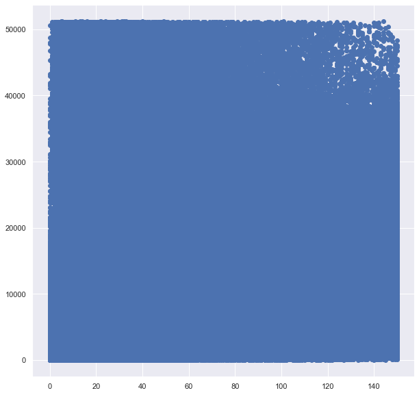

```python
plt.figure(figsize=(10,10))
plt.scatter(df['사용시간'], df['이동거리'])
```

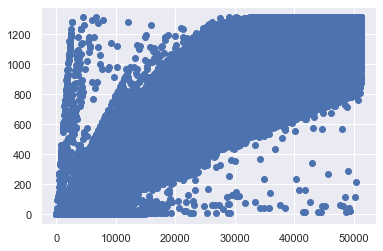

```python
plt.scatter(df['이동거리'], df['운동량'])
```

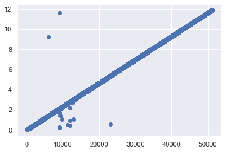

```python
plt.scatter(df['이동거리'], df['탄소량'])
```

### 이동거리<->운동량

```python
m = np.array(df['이동거리']).reshape(-1,1)
Cal = np.array(df['운동량']).reshape(-1,1)

lm_Cal_from_m = LinearRegression()
lm_Cal_from_m.fit(m, Cal)
```

```
LinearRegression(copy_X=True, fit_intercept=True, n_jobs=None, normalize=False)
```

```python
print('slope:', lm_Cal_from_m.coef_)
print('intercept:', lm_Cal_from_m.intercept_)
```

```
slope: [[0.02638304]]
intercept: [1.34393056]
```

```python
pred_Cal_from_m = lm_Cal_from_m.predict(m)

df_pred_Cal_from_m = pd.DataFrame({'이동거리':m.flatten(), '실제 운동량':Cal.flatten(), '예측 운동량':pred_Cal_from_m.flatten()})
df_pred_Cal_from_m
```

|  | 이동거리 | 실제 운동량 | 예측 운동량 |
| --- | --- | --- | --- |
| 0 | 2390.0 | 47.32 | 64.399385 |
| 1 | 2250.0 | 57.92 | 60.705760 |
| 2 | 6600.0 | 133.29 | 175.471964 |
| 3 | 1380.0 | 33.88 | 37.752519 |
| 4 | 1610.0 | 31.24 | 43.820617 |
| 5 | 3300.0 | 113.69 | 88.407947 |
| 6 | 4550.0 | 109.93 | 121.386741 |
| 7 | 2200.0 | 56.63 | 59.386608 |
| 8 | 3590.0 | 72.50 | 96.059027 |
| 9 | 2640.0 | 62.73 | 70.995144 |
| 10 | 3340.0 | 85.97 | 89.463269 |
| 11 | 660.0 | 15.68 | 18.756734 |
| 12 | 1910.0 | 68.07 | 51.735528 |
| 13 | 330.0 | 11.76 | 10.050332 |
| 14 | 3670.0 | 135.16 | 98.169670 |
| 15 | 2050.0 | 51.14 | 55.429153 |
| 16 | 770.0 | 15.25 | 21.658868 |
| 17 | 2410.0 | 71.58 | 64.927046 |
| 18 | 3860.0 | 107.00 | 103.182447 |
| 19 | 2620.0 | 67.44 | 70.467483 |
| 20 | 3110.0 | 80.05 | 83.395170 |
| 21 | 2430.0 | 82.76 | 65.454706 |
| 22 | 2660.0 | 68.47 | 71.522805 |
| 23 | 1380.0 | 40.99 | 37.752519 |
| 24 | 2340.0 | 101.93 | 63.080233 |
| 25 | 8310.0 | 213.90 | 220.586954 |
| 26 | 3810.0 | 105.61 | 101.863295 |
| 27 | 2500.0 | 69.30 | 67.301519 |
| 28 | 23650.0 | 674.31 | 625.302716 |
| 29 | 2290.0 | 58.94 | 61.761081 |
| ... | ... | ... | ... |
| 15957964 | 4390.0 | 114.74 | 117.165456 |
| 15957965 | 1670.0 | 48.28 | 45.403600 |
| 15957966 | 2480.0 | 65.80 | 66.773858 |
| 15957967 | 1620.0 | 44.91 | 44.084448 |
| 15957968 | 18410.0 | 561.36 | 487.055611 |
| 15957969 | 4430.0 | 122.80 | 118.220777 |
| 15957970 | 960.0 | 26.61 | 26.671644 |
| 15957971 | 3630.0 | 115.00 | 97.114349 |
| 15957972 | 2120.0 | 58.77 | 57.275965 |
| 15957973 | 1950.0 | 50.19 | 52.790849 |
| 15957974 | 4260.0 | 134.96 | 113.735661 |
| 15957975 | 4860.0 | 125.10 | 129.565482 |
| 15957976 | 3480.0 | 104.73 | 93.156894 |
| 15957977 | 850.0 | 23.56 | 23.769511 |
| 15957978 | 9320.0 | 202.99 | 247.233820 |
| 15957979 | 2440.0 | 71.50 | 65.718537 |
| 15957980 | 6980.0 | 199.01 | 185.497517 |
| 15957981 | 3150.0 | 93.56 | 84.450492 |
| 15957982 | 480.0 | 18.25 | 14.007788 |
| 15957983 | 5790.0 | 181.13 | 154.101705 |
| 15957984 | 1300.0 | 51.48 | 35.641876 |
| 15957985 | 1680.0 | 35.93 | 45.667430 |
| 15957986 | 2160.0 | 55.60 | 58.331287 |
| 15957987 | 2820.0 | 89.34 | 75.744090 |
| 15957988 | 6990.0 | 202.07 | 185.761348 |
| 15957989 | 1160.0 | 32.16 | 31.948252 |
| 15957990 | 3800.0 | 127.91 | 101.599465 |
| 15957991 | 1160.0 | 22.97 | 31.948252 |
| 15957992 | 6130.0 | 179.63 | 163.071937 |
| 15957993 | 3350.0 | 86.23 | 89.727099 |

15957994 rows × 3 columns

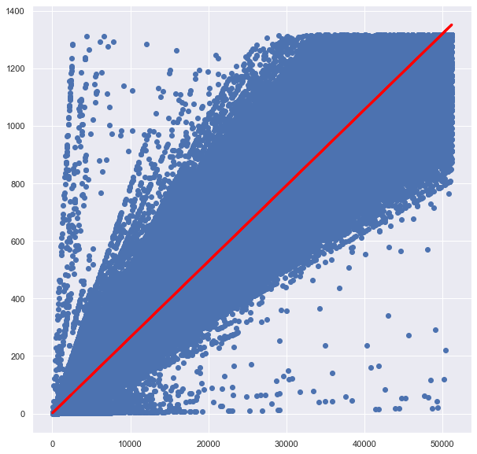

```python
plt.figure(figsize=(10,10))
plt.scatter(m, Cal)
plt.plot(m, pred_Cal_from_m, color='red', linewidth=3)
plt.show()
```

### 이동거리<->탄소량

```python
m = np.array(df['이동거리']).reshape(-1,1)
C = np.array(df['탄소량']).reshape(-1,1)

lm_C_from_m = LinearRegression()
lm_C_from_m.fit(m, C)
```

```
LinearRegression(copy_X=True, fit_intercept=True, n_jobs=None, normalize=False)
```

```python
print('slope:', lm_C_from_m.coef_)
print('intercept:', lm_C_from_m.intercept_)
```

```
slope: [[0.000232]]
intercept: [6.69403687e-06]
```

```python
pred_C_from_m = lm_C_from_m.predict(m)

df_pred_C_from_m = pd.DataFrame({'이동거리':m.flatten(), '실제 탄소량':C.flatten(), '예측 탄소량':pred_C_from_m.flatten()})
df_pred_C_from_m
```

|  | 이동거리 | 실제 탄소량 | 예측 탄소량 |
| --- | --- | --- | --- |
| 0 | 2390.0 | 0.55 | 0.554484 |
| 1 | 2250.0 | 0.52 | 0.522004 |
| 2 | 6600.0 | 1.53 | 1.531200 |
| 3 | 1380.0 | 0.32 | 0.320165 |
| 4 | 1610.0 | 0.37 | 0.373525 |
| 5 | 3300.0 | 0.77 | 0.765603 |
| 6 | 4550.0 | 1.05 | 1.055602 |
| 7 | 2200.0 | 0.51 | 0.510404 |
| 8 | 3590.0 | 0.83 | 0.832883 |
| 9 | 2640.0 | 0.61 | 0.612484 |
| 10 | 3340.0 | 0.77 | 0.774883 |
| 11 | 660.0 | 0.15 | 0.153126 |
| 12 | 1910.0 | 0.44 | 0.443125 |
| 13 | 330.0 | 0.08 | 0.076566 |
| 14 | 3670.0 | 0.85 | 0.851443 |
| 15 | 2050.0 | 0.48 | 0.475605 |
| 16 | 770.0 | 0.18 | 0.178646 |
| 17 | 2410.0 | 0.56 | 0.559124 |
| 18 | 3860.0 | 0.90 | 0.895523 |
| 19 | 2620.0 | 0.61 | 0.607844 |
| 20 | 3110.0 | 0.72 | 0.721524 |
| 21 | 2430.0 | 0.56 | 0.563764 |
| 22 | 2660.0 | 0.62 | 0.617124 |
| 23 | 1380.0 | 0.32 | 0.320165 |
| 24 | 2340.0 | 0.54 | 0.542884 |
| 25 | 8310.0 | 1.93 | 1.927918 |
| 26 | 3810.0 | 0.88 | 0.883923 |
| 27 | 2500.0 | 0.58 | 0.580004 |
| 28 | 23650.0 | 5.49 | 5.486783 |
| 29 | 2290.0 | 0.53 | 0.531284 |
| ... | ... | ... | ... |
| 15957964 | 4390.0 | 1.02 | 1.018482 |
| 15957965 | 1670.0 | 0.39 | 0.387445 |
| 15957966 | 2480.0 | 0.58 | 0.575364 |
| 15957967 | 1620.0 | 0.38 | 0.375845 |
| 15957968 | 18410.0 | 4.27 | 4.271108 |
| 15957969 | 4430.0 | 1.03 | 1.027762 |
| 15957970 | 960.0 | 0.22 | 0.222726 |
| 15957971 | 3630.0 | 0.84 | 0.842163 |
| 15957972 | 2120.0 | 0.49 | 0.491845 |
| 15957973 | 1950.0 | 0.45 | 0.452405 |
| 15957974 | 4260.0 | 0.98 | 0.988322 |
| 15957975 | 4860.0 | 1.13 | 1.127522 |
| 15957976 | 3480.0 | 0.81 | 0.807363 |
| 15957977 | 850.0 | 0.20 | 0.197206 |
| 15957978 | 9320.0 | 2.16 | 2.162237 |
| 15957979 | 2440.0 | 0.57 | 0.566084 |
| 15957980 | 6980.0 | 1.62 | 1.619360 |
| 15957981 | 3150.0 | 0.73 | 0.730804 |
| 15957982 | 480.0 | 0.11 | 0.111366 |
| 15957983 | 5790.0 | 1.34 | 1.343281 |
| 15957984 | 1300.0 | 0.30 | 0.301605 |
| 15957985 | 1680.0 | 0.39 | 0.389765 |
| 15957986 | 2160.0 | 0.50 | 0.501125 |
| 15957987 | 2820.0 | 0.65 | 0.654244 |
| 15957988 | 6990.0 | 1.62 | 1.621680 |
| 15957989 | 1160.0 | 0.27 | 0.269126 |
| 15957990 | 3800.0 | 0.88 | 0.881603 |
| 15957991 | 1160.0 | 0.27 | 0.269126 |
| 15957992 | 6130.0 | 1.42 | 1.422161 |
| 15957993 | 3350.0 | 0.78 | 0.777203 |

15957994 rows × 3 columns

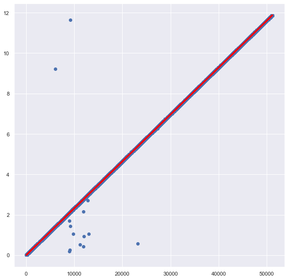

```python
plt.figure(figsize=(10,10))
plt.scatter(m, C)
plt.plot(m, pred_C_from_m, color='red', linewidth=3)
plt.show()
```

### 사용시간<->이동거리

```python
time = np.array(df['사용시간']).reshape(-1,1)
m = np.array(df['이동거리']).reshape(-1,1)

lm_m_from_time = LinearRegression()
lm_m_from_time.fit(time, m)
```

```
LinearRegression(copy_X=True, fit_intercept=True, n_jobs=None, normalize=False)
```

```python
print('slope:', lm_m_from_time.coef_)
print('intercept:', lm_m_from_time.intercept_)
```

```
slope: [[114.43073581]]
intercept: [927.15310827]
```

```python
pred_m_from_time = lm_m_from_time.predict(time)

df_pred_m_from_time = pd.DataFrame({'사용시간':time.flatten(), '실제 이동거리':m.flatten(), '예측 이동거리':pred_m_from_time.flatten()})
df_pred_m_from_time
```

|  | 사용시간 | 실제 이동거리 | 예측 이동거리 |
| --- | --- | --- | --- |
| 0 | 15 | 2390.0 | 2643.614145 |
| 1 | 13 | 2250.0 | 2414.752674 |
| 2 | 43 | 6600.0 | 5847.674748 |
| 3 | 8 | 1380.0 | 1842.598995 |
| 4 | 11 | 1610.0 | 2185.891202 |
| 5 | 21 | 3300.0 | 3330.198560 |
| 6 | 43 | 4550.0 | 5847.674748 |
| 7 | 18 | 2200.0 | 2986.906353 |
| 8 | 24 | 3590.0 | 3673.490768 |
| 9 | 16 | 2640.0 | 2758.044881 |
| 10 | 20 | 3340.0 | 3215.767824 |
| 11 | 30 | 660.0 | 4360.075183 |
| 12 | 14 | 1910.0 | 2529.183410 |
| 13 | 4 | 330.0 | 1384.876052 |
| 14 | 19 | 3670.0 | 3101.337089 |
| 15 | 20 | 2050.0 | 3215.767824 |
| 16 | 6 | 770.0 | 1613.737523 |
| 17 | 16 | 2410.0 | 2758.044881 |
| 18 | 15 | 3860.0 | 2643.614145 |
| 19 | 16 | 2620.0 | 2758.044881 |
| 20 | 16 | 3110.0 | 2758.044881 |
| 21 | 22 | 2430.0 | 3444.629296 |
| 22 | 14 | 2660.0 | 2529.183410 |
| 23 | 11 | 1380.0 | 2185.891202 |
| 24 | 12 | 2340.0 | 2300.321938 |
| 25 | 36 | 8310.0 | 5046.659597 |
| 26 | 21 | 3810.0 | 3330.198560 |
| 27 | 11 | 2500.0 | 2185.891202 |
| 28 | 8 | 23650.0 | 1842.598995 |
| 29 | 11 | 2290.0 | 2185.891202 |
| ... | ... | ... | ... |
| 15957964 | 30 | 4390.0 | 4360.075183 |
| 15957965 | 6 | 1670.0 | 1613.737523 |
| 15957966 | 27 | 2480.0 | 4016.782975 |
| 15957967 | 20 | 1620.0 | 3215.767824 |
| 15957968 | 77 | 18410.0 | 9738.319766 |
| 15957969 | 33 | 4430.0 | 4703.367390 |
| 15957970 | 4 | 960.0 | 1384.876052 |
| 15957971 | 26 | 3630.0 | 3902.352239 |
| 15957972 | 9 | 2120.0 | 1957.029731 |
| 15957973 | 8 | 1950.0 | 1842.598995 |
| 15957974 | 23 | 4260.0 | 3559.060032 |
| 15957975 | 26 | 4860.0 | 3902.352239 |
| 15957976 | 25 | 3480.0 | 3787.921504 |
| 15957977 | 9 | 850.0 | 1957.029731 |
| 15957978 | 45 | 9320.0 | 6076.536220 |
| 15957979 | 17 | 2440.0 | 2872.475617 |
| 15957980 | 40 | 6980.0 | 5504.382541 |
| 15957981 | 16 | 3150.0 | 2758.044881 |
| 15957982 | 2 | 480.0 | 1156.014580 |
| 15957983 | 23 | 5790.0 | 3559.060032 |
| 15957984 | 10 | 1300.0 | 2071.460466 |
| 15957985 | 9 | 1680.0 | 1957.029731 |
| 15957986 | 11 | 2160.0 | 2185.891202 |
| 15957987 | 16 | 2820.0 | 2758.044881 |
| 15957988 | 26 | 6990.0 | 3902.352239 |
| 15957989 | 6 | 1160.0 | 1613.737523 |
| 15957990 | 17 | 3800.0 | 2872.475617 |
| 15957991 | 17 | 1160.0 | 2872.475617 |
| 15957992 | 26 | 6130.0 | 3902.352239 |
| 15957993 | 24 | 3350.0 | 3673.490768 |

15957994 rows × 3 columns

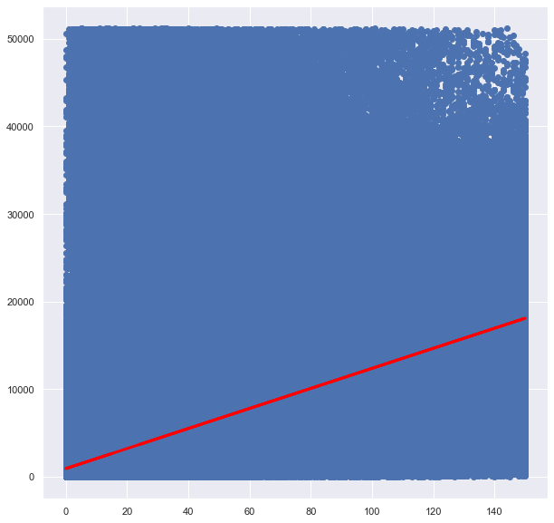

```python
plt.figure(figsize=(10,10))
plt.scatter(time, m)
plt.plot(time, pred_m_from_time, color='red', linewidth=3)
plt.show()
```

#### 데이터가 너무 많아서(약 1600만개) 그런데

#### 빨간색 선을 보면 빨간색 선 근처로 데이터가 밀집 되어있는 것을 알 수 있다.

#### (아웃라이어를 아직 처리하지 못했다.)

## 이와 같은 분석으로

## 따릉이 이용자가 자신의 예상 따릉이 사용시간을 입력하면

## 예상 이동거리를 예측하여, 예상 운동량과 예상 탄소량을 예측하여 알려주는 시스템을

## 따릉이 어플에 넣을 것을 서울시에게 제안한다.